# Anomalías térmicas en Costa Rica — comparación entre plataformas

MODIS y VIIRS lado a lado en los años que observaron a la vez

Autor/a

Organización Incendios Forestales

Fecha de publicación

15 de septiembre de 2026

## Qué es esto

Las cuatro series de este proyecto **no se suman ni se empalman**: cada plataforma ve el fuego con su píxel y sus horas de paso, y una serie combinada mostraría el instrumental y no el régimen de fuego. Lo que sí se puede hacer, y es lo que hace este reporte, es **compararlas en los años que observaron a la vez**. Responde a dos preguntas: si los hallazgos de la serie larga de MODIS se sostienen en el sensor VIIRS que la relevará cuando Terra y Aqua terminen en 2027, y qué parte de la diferencia entre plataformas es propiedad del fuego y qué parte del píxel.

Los índices son los de la suite de temporada de cada plataforma, y las definiciones están en el [README](https://github.com/incendios-forestales/anomalias-termicas-costarica#comparación-entre-plataformas-en-el-traslape). Se comparan **pares ordenados** de plataformas, siempre como **B − A**, en el **periodo de traslape**: los años de fuego (setiembre–agosto) completos y no provisionales en ambas. La literatura da la expectativa: el píxel de 375 m de VIIRS detecta fuegos más pequeños y más fríos que el de 1 km de MODIS (Schroeder et al. 2014; Giglio et al. 2016), produce varias veces más detecciones sobre los mismos fuegos (Fu et al. 2020) y reporta una potencia radiativa por píxel que no equivale a la de MODIS (Li et al. 2018). De ahí cabía esperar que VIIRS adelantara el inicio de la temporada; el resultado, abajo, es otro. Por eso se comparan en nivel solo los índices por fracciones y fechas (`INI`, `FIN`, `LON`, `N50`, `C10`), los de conteo (`DTOT`, `ND95`, `D95pTOT`) solo como anomalías estandarizadas, y la FRP no se compara.

- **MODIS → VIIRS S-NPP**: traslape 2013–2025 (13 años). Es el par principal.
- **MODIS → VIIRS NOAA-20**: traslape 2019–2025 (7 años).
- **VIIRS S-NPP → VIIRS NOAA-20**: traslape 2019–2025 (7 años). Control: el mismo instrumento en dos plataformas.

Con trece años las correlaciones se reportan; con siete solo se describen. El tercer par es un **control**: Suomi-NPP y NOAA-20 llevan el mismo VIIRS y pasan con cincuenta minutos de diferencia, así que lo que difiera entre ellos no es el píxel sino las pasadas que cada satélite alcanzó a ver.

## MODIS → VIIRS S-NPP

### Índices anuales lado a lado

Los 13 años de fuego del traslape (2013–2025) son los años completos de Suomi-NPP; para MODIS son la segunda mitad de su registro. Cada índice se calculó por plataforma, con sus propias detecciones de vegetación, y aquí solo se ponen uno junto al otro.

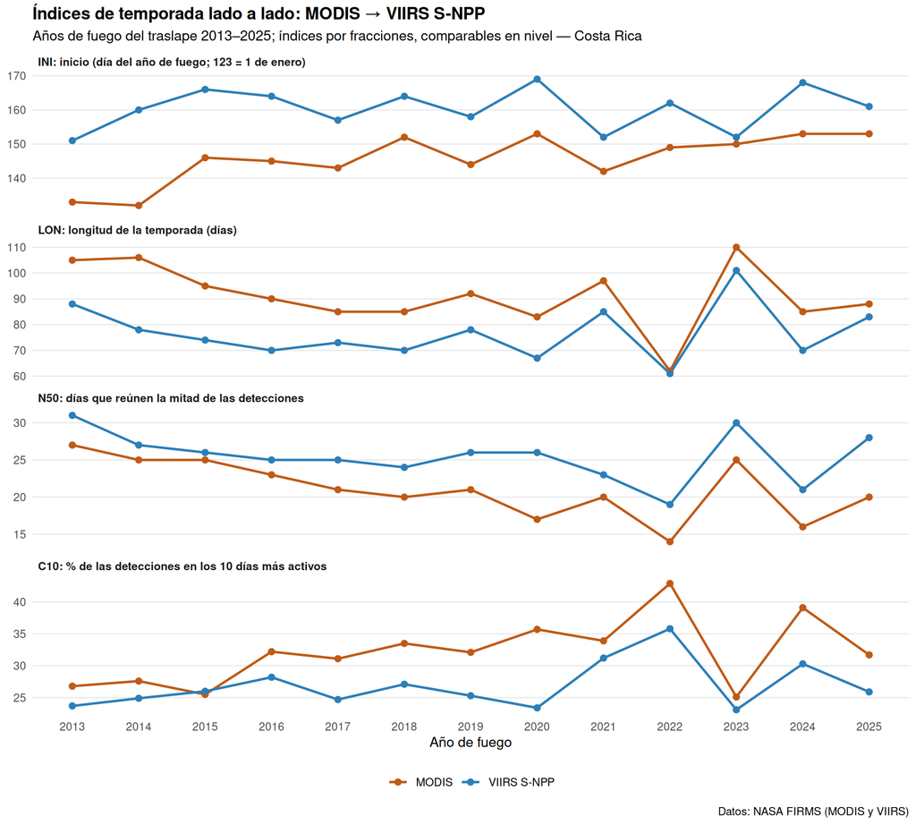

**El resultado contradice la expectativa.** El píxel fino no adelanta el inicio: a escala nacional VIIRS fecha `INI` con una mediana de **14 días** respecto de MODIS (entre 2 y 28; positivo significa después), y es un rezago sistemático, presente en todos los años del traslape, aunque las dos plataformas ordenen los años de forma parecida (ρ de Spearman 0,66). El **fin** coincide: difiere en 0 días en mediana y su ρ es 0,94. Como el fin coincide y el inicio no, la **longitud** de la temporada es -15 días en mediana para VIIRS (entre -28 y -1; ρ 0,87): más corta, no más larga. La sección por celda, abajo, dice dónde está la diferencia: en las celdas comparables los inicios casi coinciden, así que el rezago nacional es un efecto de composición y no de detección temprana. Las detecciones que VIIRS añade se concentran en las celdas y los días del pico de la temporada, y ese peso extra en febrero y marzo hace que el 10 % acumulado nacional se alcance más tarde.

**Concentración.** VIIRS ve el fuego algo más repartido en el tiempo: `N50` es 4 días mayor en mediana (ρ 0,74) y `C10` -5,8 puntos porcentuales menor (ρ 0,64), lo esperable de un sensor que detecta fuegos pequeños en más días. Pero las correlaciones dicen que una temporada larga o concentrada lo es para las dos plataformas: el orden de los años es propiedad del fuego, y el nivel, del sensor.

| Año de fuego | Inicio MODIS | Inicio VIIRS S-NPP | ΔINI (días) | Fin MODIS | Fin VIIRS S-NPP | ΔFIN (días) | LON MODIS | LON VIIRS S-NPP | ΔLON (días) | N50 MODIS | N50 VIIRS S-NPP | C10 % MODIS | C10 % VIIRS S-NPP |
| --- | --- | --- | --- | --- | --- | --- | --- | --- | --- | --- | --- | --- | --- |
| 2013 | 11 de enero | 29 de enero | 18 | 25 de abril | 26 de abril | 1 | 105 | 88 | -17 | 27 | 31 | 26.8 | 23.7 |
| 2014 | 10 de enero | 7 de febrero | 28 | 25 de abril | 25 de abril | 0 | 106 | 78 | -28 | 25 | 27 | 27.6 | 24.9 |
| 2015 | 24 de enero | 13 de febrero | 20 | 28 de abril | 27 de abril | -1 | 95 | 74 | -21 | 25 | 26 | 25.5 | 26 |
| 2016 | 23 de enero | 11 de febrero | 19 | 22 de abril | 21 de abril | -1 | 90 | 70 | -20 | 23 | 25 | 32.2 | 28.2 |
| 2017 | 21 de enero | 4 de febrero | 14 | 15 de abril | 17 de abril | 2 | 85 | 73 | -12 | 21 | 25 | 31.1 | 24.7 |
| 2018 | 30 de enero | 11 de febrero | 12 | 24 de abril | 21 de abril | -3 | 85 | 70 | -15 | 20 | 24 | 33.5 | 27.1 |
| 2019 | 22 de enero | 5 de febrero | 14 | 23 de abril | 23 de abril | 0 | 92 | 78 | -14 | 21 | 26 | 32.1 | 25.3 |
| 2020 | 31 de enero | 16 de febrero | 16 | 23 de abril | 23 de abril | 0 | 83 | 67 | -16 | 17 | 26 | 35.7 | 23.4 |
| 2021 | 20 de enero | 30 de enero | 10 | 26 de abril | 24 de abril | -2 | 97 | 85 | -12 | 20 | 23 | 33.9 | 31.2 |
| 2022 | 27 de enero | 9 de febrero | 13 | 29 de marzo | 10 de abril | 12 | 62 | 61 | -1 | 14 | 19 | 42.9 | 35.8 |

[output cut: 3 more lines]

| Índice | Comparación | Años | Mediana de B − A | Rango de B − A | ρ de Spearman | % años con el mismo signo | Año máximo MODIS | Año máximo VIIRS S-NPP |
| --- | --- | --- | --- | --- | --- | --- | --- | --- |
| INI | en nivel | 13 | 14,0 | 2,0 a 28,0 | 0,66 |  | 2020 | 2020 |
| FIN | en nivel | 13 | 0,0 | -7,0 a 12,0 | 0,94 |  | 2023 | 2023 |
| LON | en nivel | 13 | -15,0 | -28,0 a -1,0 | 0,87 |  | 2023 | 2023 |
| N50 | en nivel | 13 | 4,0 | 1,0 a 9,0 | 0,74 |  | 2013 | 2013 |
| C10 | en nivel | 13 | -5,8 | -12,3 a 0,5 | 0,64 |  | 2022 | 2022 |
| DTOT | anomalía estandarizada | 13 |  |  | 0,98 | 92 | 2013 | 2013 |
| ND95 | anomalía estandarizada | 13 |  |  | 0,76 | 92 | 2015 | 2016 |
| D95pTOT | anomalía estandarizada | 13 |  |  | 0,90 | 100 | 2022 | 2016 |

La tabla completa, con los tres índices de conteo y sus anomalías, está disponible como CSV.

### Anomalías estandarizadas de los índices de conteo

VIIRS cuenta entre cinco y ocho veces más detecciones que MODIS, así que `DTOT`, `ND95` y `D95pTOT` no se comparan en nivel. Sí se comparan como **anomalía estandarizada**: el valor de cada año menos la media del traslape, dividido entre su desviación típica, por plataforma. La pregunta pasa a ser si un año fue extremo para las dos a la vez.

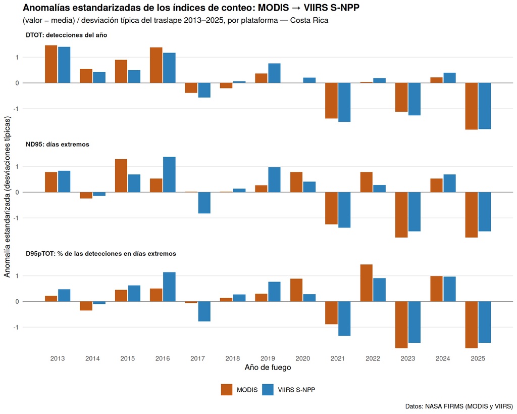

Las anomalías del total anual coinciden en signo en el **92 %** de los años (ρ 0,98): MODIS sitúa su máximo en 2013 y VIIRS en 2013, y su mínimo en 2025 y 2025. Los días extremos coinciden en signo en el 92 % de los años (ρ 0,76; año máximo 2015 para MODIS y 2016 para VIIRS), y la fracción del año en días extremos tiene ρ 0,90. Cuando dos instrumentos independientes coinciden en qué años fueron extremos, el hallazgo no es artefacto de ninguno.

### Consolidados por celda en el traslape

Los mapas por celda de cada plataforma usan periodos distintos (MODIS, 2002–2025; S-NPP, 2013–2025). Para compararlos se **recalcularon ambos sobre los años del traslape**, con la misma grilla de 0,1° y el mismo umbral de 30 detecciones, y se clasificó cada celda según dónde hay índices.

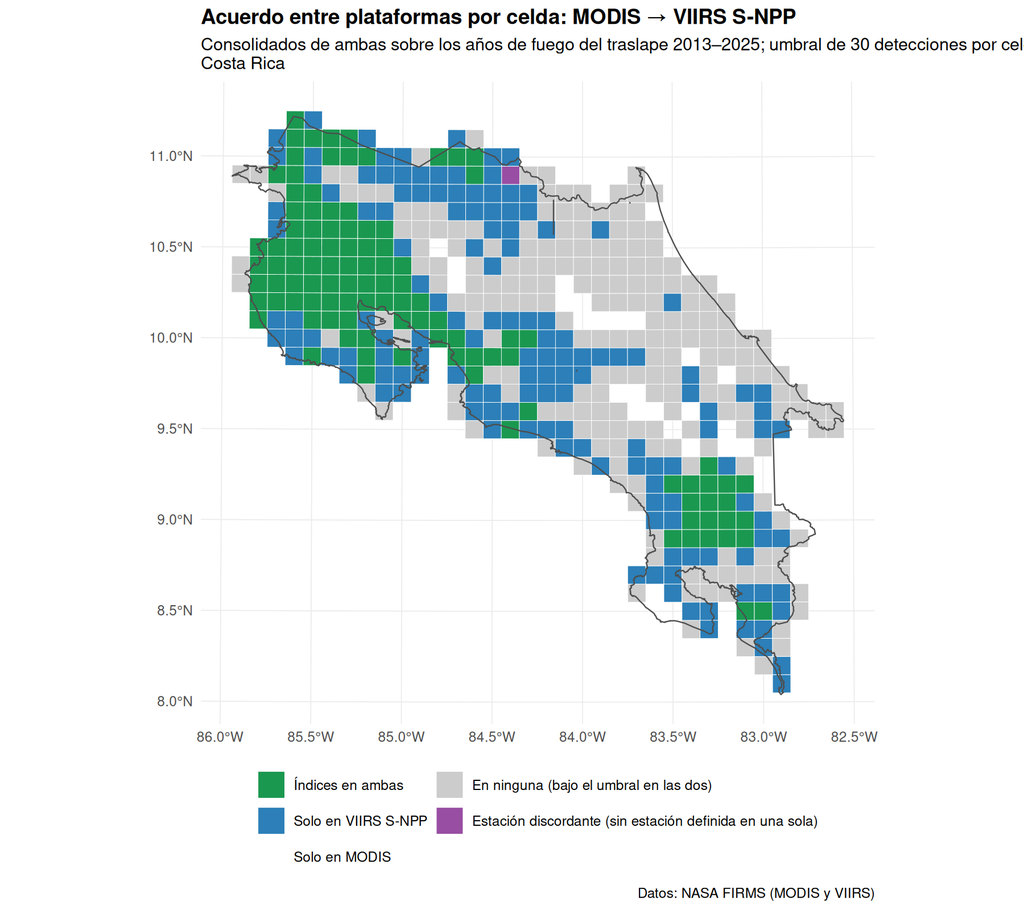

De las 457 celdas con fuego en alguna de las dos, **107 tienen índices en ambas**, 144 solo en VIIRS, 0 solo en MODIS, 205 en ninguna y 1 tienen estación definida en una sola. Las celdas «solo en VIIRS» son el mapa de lo que el píxel fino añade: fuego que MODIS ve demasiado poco para fechar. En las 107 celdas comparables **los inicios casi coinciden**: la mediana de `ΔINI` es de 2 días (rango intercuartílico 0 a 8), el 83 % de las celdas coincide en el inicio a 15 días o menos y VIIRS empieza antes solo en el 24 % de ellas. El fin difiere en 0 días y la longitud en -3 (rango intercuartílico -12 a 3). Es lo que permite leer el rezago nacional de 14 días como composición: celda a celda las dos plataformas ven la misma temporada, y la diferencia aparece al sumar el país, donde las celdas del pico pesan más en VIIRS.

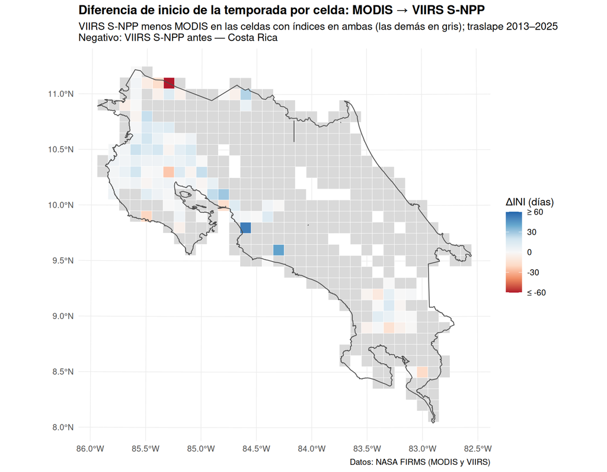

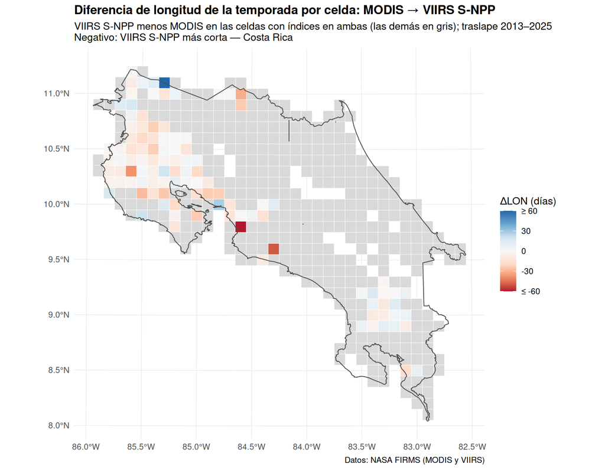

Las densidades no se comparan en nivel, pero sí en orden: sobre las 447 celdas con al menos 10 km² de tierra, la correlación de Spearman entre la densidad de MODIS y la de VIIRS en el traslape es **0,89**. Las dos plataformas dibujan la misma geografía del fuego aunque cuenten detecciones distintas.

Los productos por celda están disponibles como CSV y como GeoTIFF con cuatro bandas: `acuerdo` (1 índices en ambas, 2 solo en B, 3 solo en A, 4 en ninguna, 5 estación discordante), `dif_ini`, `dif_fin` y `dif_lon`, en días, B − A.

## Los otros pares

### MODIS → VIIRS NOAA-20

Traslape 2019–2025 (7 años; solo descripción). Mediana de B − A: inicio 12 días, fin 0, longitud -10, N50 6, C10 -7,5 puntos. Anomalías del total anual con el mismo signo en el 100 % de los años; años máximos 2019 (MODIS) y 2019 (VIIRS NOAA-20). Por celda: 64 con índices en ambas, 108 solo en VIIRS NOAA-20, 0 solo en MODIS; mediana de ΔINI 1 días (86 % de las celdas a 15 días o menos) y de ΔLON 0; ρ de Spearman de las densidades 0,85.

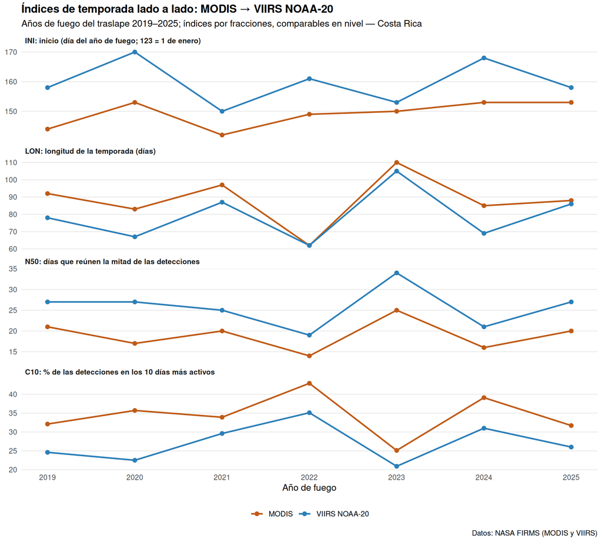

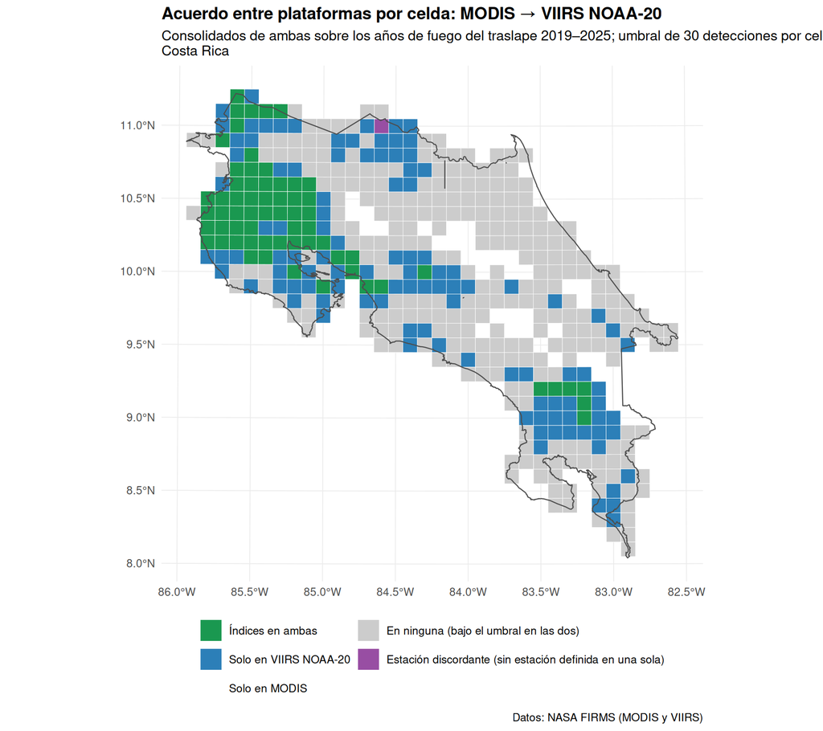

Tablas: anual, por celda; GeoTIFF; figuras de anomalías, ΔINI y ΔLON.

### VIIRS S-NPP → VIIRS NOAA-20

Traslape 2019–2025 (7 años; solo descripción). Mediana de B − A: inicio 0 días, fin 0, longitud 1, N50 1, C10 -0,7 puntos. Anomalías del total anual con el mismo signo en el 100 % de los años; años máximos 2019 (VIIRS S-NPP) y 2019 (VIIRS NOAA-20). Por celda: 162 con índices en ambas, 9 solo en VIIRS NOAA-20, 12 solo en VIIRS S-NPP; mediana de ΔINI 0 días (88 % de las celdas a 15 días o menos) y de ΔLON 1; ρ de Spearman de las densidades 0,96.

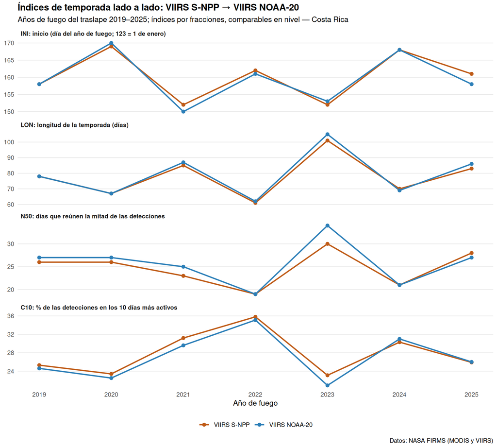

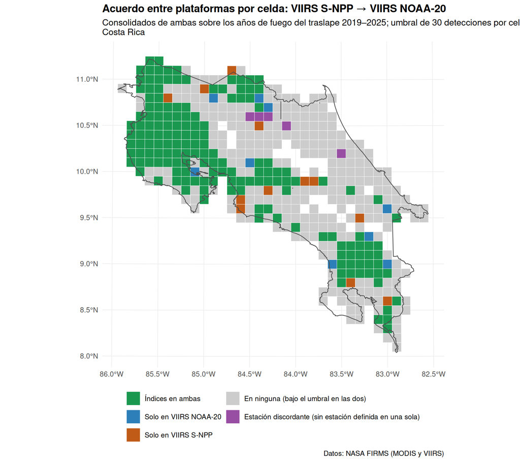

Tablas: anual, por celda; GeoTIFF; figuras de anomalías, ΔINI y ΔLON.

El par S-NPP → NOAA-20 es la vara de medir: dos satélites con el mismo instrumento deberían diferir poco, y lo que difieran acota cuánto de la diferencia MODIS → VIIRS puede atribuirse a las pasadas y no al píxel.

## Lo que no se hace

No hay serie intercalibrada ni factor de conversión entre plataformas: las diferencias se publican como tales. No se comparan la FRP ni los umbrales `P95`, que son propios de cada sensor. Estos productos no alimentan ningún índice de las plataformas ni se actualizan con la cola en tiempo casi real: cambian solo cuando se cierra un año de fuego completo en ambas. NOAA-21 entrará en la comparación cuando FIRMS publique su procesamiento estándar y tenga años completos.

## Fuentes de datos

- **NASA FIRMS** — MODIS Collection 6.1 (MODIS_SP y MODIS_NRT) y VIIRS 375 m de Suomi-NPP y NOAA-20 (VIIRS_SNPP_SP/NRT, VIIRS_NOAA20_SP/NRT). https://firms.modaps.eosdis.nasa.gov/.
- Fu, Y. et al. (2020). Fire detection and fire radiative power in forests and low-biomass lands in Northeast Asia: MODIS versus VIIRS fire products. *Remote Sensing*, 12(18), 2870.
- Giglio, L., Schroeder, W. y Justice, C. O. (2016). The collection 6 MODIS active fire detection algorithm and fire products. *Remote Sensing of Environment*, 178, 31–41.
- Li, F., Zhang, X., Kondragunta, S. y Csiszar, I. (2018). Comparison of fire radiative power estimates from VIIRS and MODIS observations. *Journal of Geophysical Research: Atmospheres*, 123(9), 4545–4563.
- Schroeder, W., Oliva, P., Giglio, L. y Csiszar, I. A. (2014). The New VIIRS 375 m active fire detection data product. *Remote Sensing of Environment*, 143, 85–96.